# Load packages

```r
require(tidyverse)
require(gridExtra)
require(scales)
```

```r
require(figuRes2)
require(latex2exp)
```

# Getting started with graphics with the computer screen in mind

## Warm-up with some comparison with Base R:

### Histogram, boxplot, scatterplot in base R

Base R is great for getting a quick view of your data:

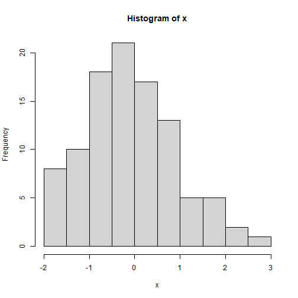

```r
x <- rnorm(100)
hist(x)
```

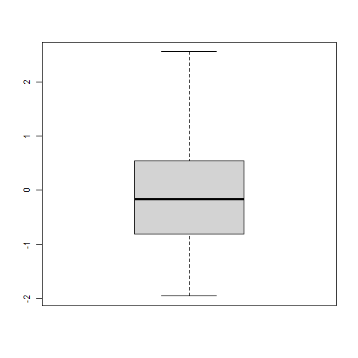

```r
boxplot(x)
```

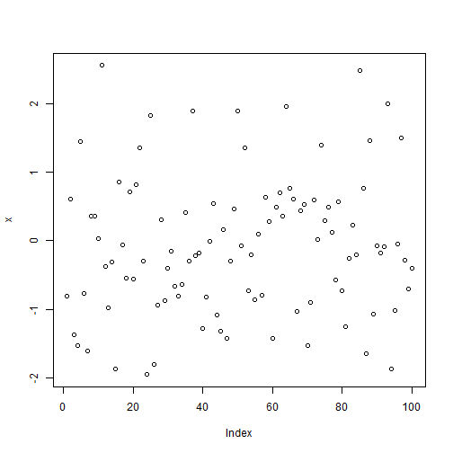

```r
plot(x)
```

## Histogram, boxplot, scatterplot in ggplot

But ggplot2 offers aesthetic and programming advantages.

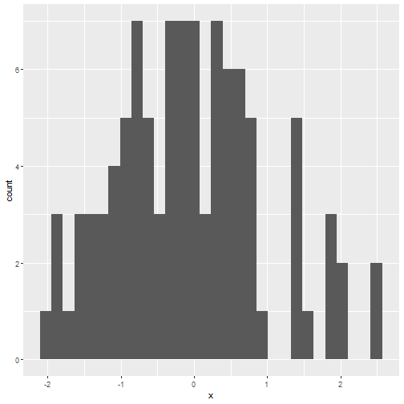

```r
my.df <- data.frame(x=x)
ggplot(data=my.df, aes(x=x)) + geom_histogram()
```

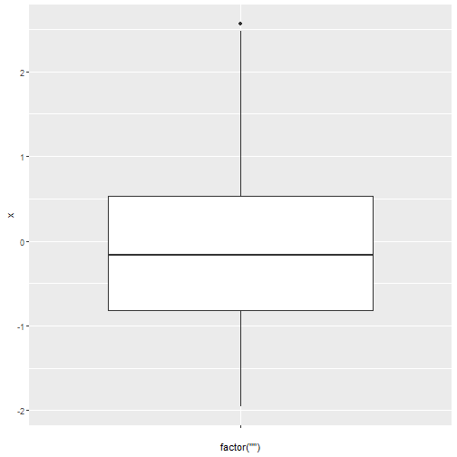

```r
ggplot(data=my.df, aes(x=factor(""), y=x)) + geom_boxplot()
```

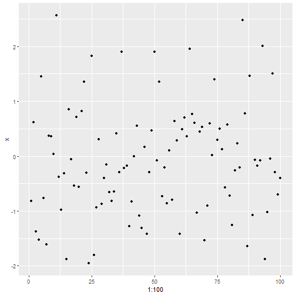

```r
ggplot(data=my.df, aes(x=1:100, y=x))+geom_point()
```

# Getting aquainted with a dummy demography data set

This is dummy data set we will use to create some graphics.

```r
# dframe=read.csv("demog.csv")
data(demog.data)
```

## Explore data

```r
head(demog.data)
```

```
##       CENTREID SUBJID AGE SEX    TRTGRP         REGION HEIGHT WEIGHT DIABET
## 5699     60016  17380  58   M Treatment   Asia/Pacific    165   65.0      1
## 8622     67458  24040  62   M   Placebo Western Europe    181   88.0      0
## 11716    58401  30384  63   M   Placebo Western Europe    175   77.0      0
## 9633     57867  26373  63   F   Placebo Western Europe    159   81.4      0
## 13562    59286  34327  70   M Treatment Western Europe    160   81.3      1
## 4004     59512  13390  80   M Treatment   Asia/Pacific    151   62.0      0
##       SYSBP DIABP      BMI      BMI.GRP GFR.GRP HDLC
## 5699    116    78 23.87511    <25 kg/m2    Mild 1.04
## 8622    132    79 26.86121 25-<30 kg/m2    Mild 1.14
## 11716   140    81 25.14286 25-<30 kg/m2  Normal 1.83
## 9633    165   101 32.19809   >=30 kg/m2    Mild 1.82
## 13562   132    78 31.75781   >=30 kg/m2    Mild 1.30
## 4004    144    83 27.19179 25-<30 kg/m2    Mild 1.38
```

### Getting aquainted with REGION column

This a column holding info on Region.

```r
table(demog.data$REGION)
```

```
##
##   Asia/Pacific Eastern Europe  North America  South America Western Europe
##           1013           1098           1224            375           1290
```

```r
data.frame(table(demog.data$REGION))
```

```
##             Var1 Freq
## 1   Asia/Pacific 1013
## 2 Eastern Europe 1098
## 3  North America 1224
## 4  South America  375
## 5 Western Europe 1290
```

# Bar charts

## Suppose we want a simple univariate barchart

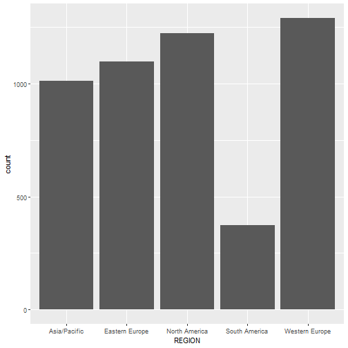

```r
ggplot(data=demog.data, aes(x=REGION)) + geom_bar()
```

## Swap X and Y Axes with coord_flip

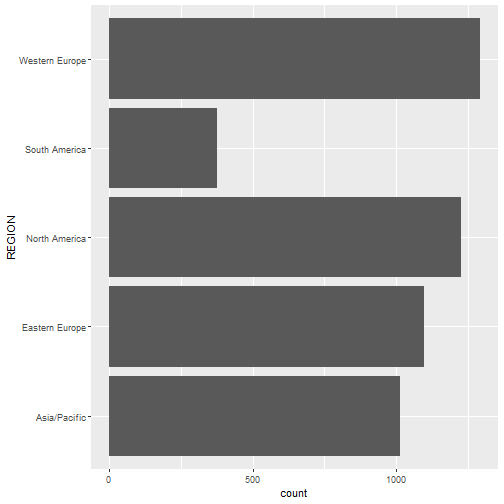

```r
ggplot(data=demog.data, aes(x=REGION)) + geom_bar() + coord_flip()
```

## Assignment of ggplot object to variable

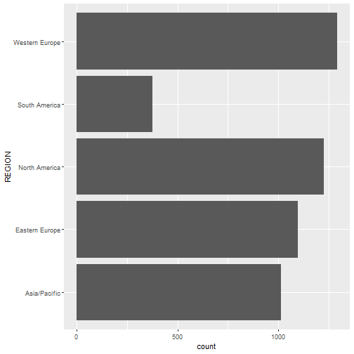

```r
p <- ggplot(data=demog.data, aes(x=REGION)) + geom_bar() + coord_flip()
# print or simply send p to command line
print(p)
```

## Manipulate labels and tick marks

### Add labels

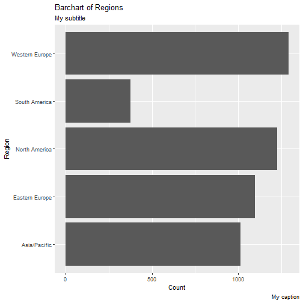

```r
p + labs(title="Barchart of Regions", y = "Count", x="Region", subtitle="My subtitle", caption="My caption")
```

### Manipulate tickmarks

We can control the tick marks using the breaks option. It is good practice to use breaks which extend up to or beyond the planned limits of the graph.

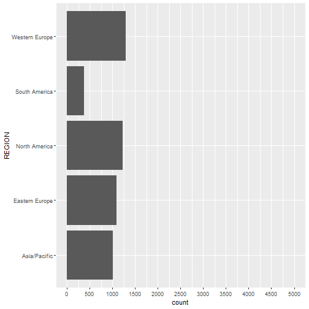

```r
p + scale_y_continuous(breaks=seq(0,6000, 500), limits= c(0, 5000))
```

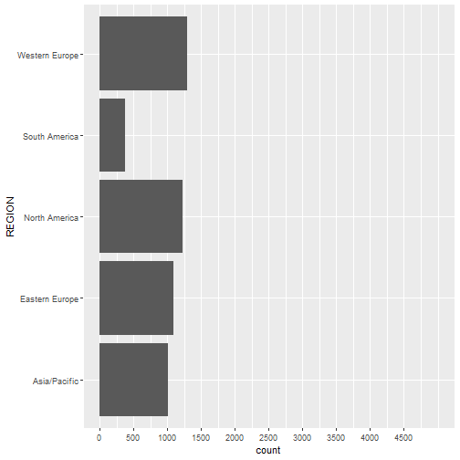

```r
# Note that tick mark at 5000 is not printed.
p + scale_y_continuous(breaks=seq(0,4500, 500), limits= c(0, 5000))
```

### Altogether now…

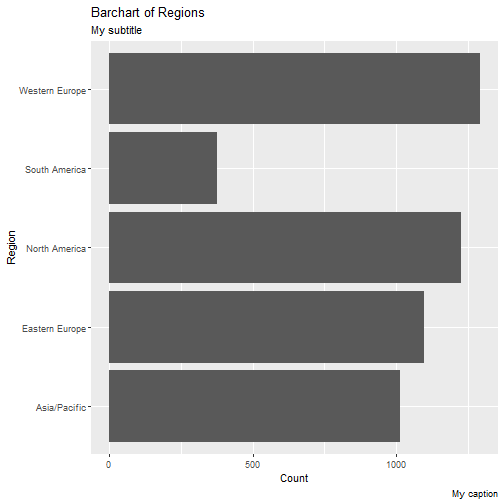

```r
p + labs(title="Barchart of Regions", y = "Count", x="Region", subtitle="My subtitle", caption="My caption")+ scale_y_continuous(breaks=seq(0,4000, 500))
```